# Báo cáo phân tích IRT — 1PL / 2PL / 3PL

Nền tảng OLM · 2 đề thi thử Tin học THPT

24/06/2026 19:46

# 1 Giới thiệu

Báo cáo phân tích **Item Response Theory (IRT)** trên **2 đề thi thử môn Tin học của nền tảng OLM**, so sánh ba mô hình **1PL (Rasch)**, **2PL**, **3PL**, kèm phần mở rộng **đối chiếu CTT–IRT**, **các cách ước lượng tham số** và **kiểm định tính bất biến / DIF**. Số thí sinh từng đề nêu ở đầu mỗi mục.

# 2 Cách đọc các bảng & đồ thị

**So sánh mô hình**

- **AIC / BIC** — chỉ số chọn mô hình, **càng nhỏ càng tốt**; chỉ so *tương đối* giữa các mô hình.
- **LRT** — kiểm định tỷ số hợp lý; p < 0,05 ⇒ mô hình phức tạp hơn cải thiện có ý nghĩa.
- **M2 / RMSEA / SRMSR / CFI / TLI** — độ phù hợp **tuyệt đối** (tốt khi RMSEA < 0,06; SRMSR < 0,08; CFI/TLI > 0,95). Cho biết mô hình “tốt nhất” có thực sự khớp dữ liệu không.

**Tham số câu hỏi**

- **a — độ phân biệt**: độ dốc đường cong; a cao ⇒ câu phân loại giỏi/kém rõ.
- **b — độ khó**: mức năng lực θ mà tại đó P(đúng) = 0,5; b cao = câu khó.
- **g — đoán mò** (3PL): xác suất đúng do đoán dù năng lực rất thấp (sàn đường cong).

**Các đường cong**

- **ICC** (đặc trưng câu hỏi): mỗi đường = 1 câu, P(đúng) tăng theo năng lực θ. Đường **dốc** = a cao; **lệch phải** = b cao (khó).
- **IIC** (thông tin từng câu): câu đo **chính xác nhất** quanh độ khó của nó; đỉnh càng cao = a càng lớn.
- **TIF & SE(θ)**: tổng thông tin cả đề và sai số đo SE = 1/√TIF. Đề đo **chính xác nhất** ở vùng θ có TIF cao / SE thấp.
- **TCC** (đặc trưng bài test): điểm kỳ vọng (số ý đúng) theo θ — cầu nối giữa thang θ và “số câu đúng”.

**Định vị & độ tin cậy**

- **Wright map**: phân bố năng lực thí sinh (trên) và độ khó câu (dưới) trên **cùng thang logit**. Câu ngang tầm HS = vừa sức; vùng HS đông mà thưa câu = đề chưa phủ tốt.
- **Độ tin cậy theo năng lực ρ(θ)**: độ tin cậy thay đổi theo mức năng lực (ngưỡng 0,8 / 0,9); vùng ρ thấp = đo kém tin ở mức θ đó.
- **Scatter a vs b**: mỗi điểm 1 câu (cỡ ~ g). Câu tốt: a ≥ 1, b vừa phải; a thấp hoặc b cực trị ⇒ nên rà soát.

**Độ phù hợp câu & thí sinh**

- **Item fit thực nghiệm vs mô hình**: điểm = tỷ lệ đúng quan sát theo nhóm năng lực; đường = mô hình dự báo. Điểm bám đường = câu khớp mô hình.
- **infit/outfit MNSQ** (Rasch): quanh 1 là khớp; > 1,5 = câu/HS đo nhiễu, không nhất quán với năng lực.
- **Item fit Bock X²**: điểm đỏ (p < 0,05) = câu **không** khớp mô hình, nên xem lại.
- **Person fit**: HS có infit/outfit ngoài 0,5–1,5 = kiểu trả lời bất thường (giỏi sai câu dễ / yếu đúng câu khó).

**Phụ thuộc cục bộ (Q3)**

IRT giả định: khi đã biết năng lực θ thì các câu trả lời **độc lập** với nhau (“độc lập địa phương”). **Q3** là **tương quan phần dư** giữa từng cặp câu sau khi đã trừ ảnh hưởng của θ. **|Q3| lớn (> 0,2)** = hai câu còn dính nhau **ngoài** năng lực chung — thường do **chung ngữ cảnh** (các ý a/b/c/d của cùng một câu Đúng/Sai chùm). Hệ quả: **phóng đại độ tin cậy và lượng thông tin** (như đếm trùng một phần năng lực). Cách xử lý: **gộp các ý cùng câu chùm thành 1 item đa mức (PCM/GPCM, 0–4 điểm)**. Trên heatmap, ô đậm ngoài đường chéo = cặp phụ thuộc mạnh; cặp **chéo-nhánh** để trống vì không thí sinh nào làm chung cả hai.

**Đơn chiều**

- **Scree / parallel analysis**: kiểm tra giả định “một năng lực”. Thành phần chính thứ nhất trội rõ (tỷ lệ λ1/λ2 lớn) ⇒ ủng hộ đơn chiều.

**Phần mở rộng**

- **CTT** (p = tỷ lệ đúng; r = tương quan câu–tổng; α = độ tin cậy nội tại): đối chiếu IRT để thấy p↔︎b, r↔︎a và tính **phụ thuộc mẫu** của CTT.
- **ML / WLE / MAP / EAP**: 4 cách ước lượng năng lực θ; Bayes (MAP/EAP) ổn định ở điểm biên nhưng **co rút** về 0.
- **DIF theo nhánh**: câu **thiên lệch** — ở **cùng θ**, hai nhóm (KHMT vs Tin ứng dụng) có xác suất đúng khác nhau.
- **Quy đổi θ → điểm thực**: tra từ năng lực sang số ý đúng kỳ vọng.

# 3 Đề thi thử Tốt nghiệp THPT lần 2 môn Tin học

- Đề thi thử **môn Tin học** trên nền tảng **OLM** · **1037 thí sinh** · **48 item**

## So sánh mô hình

Chỉ số fit theo mô hình

| Model | npars | logLik | AIC | BIC | converged |
| --- | --- | --- | --- | --- | --- |
| 1PL | 49 | -21615.8 | 43329.7 | 43571.9 | TRUE |
| 2PL | 96 | -21250.0 | 42692.0 | 43166.6 | TRUE |
| 3PL | 144 | -21348.6 | 42985.2 | 43697.1 | TRUE |

LRT 1PL→2PL: X²=731.7, df=47, p=1.23e-123 | 2PL→3PL: X²=-197.2, df=48, p=1

**Mô hình tốt nhất theo AIC: 2PL** (BIC: 2PL)

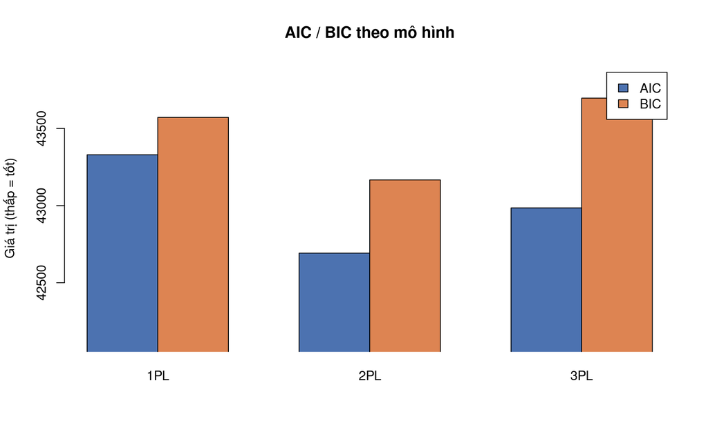

## 3.1 Mô hình 1PL

### Phân bố tham số item

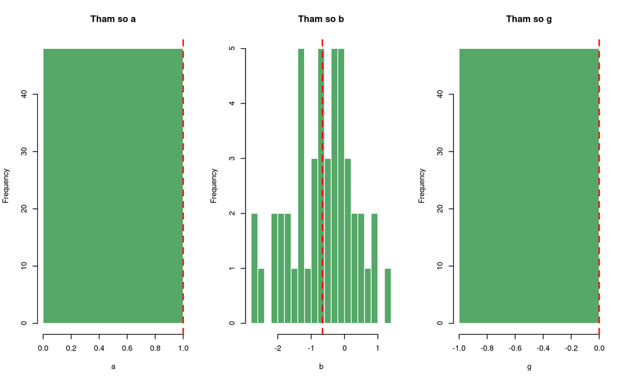

### Bảng tham số item (theo Câu)

Tham số item 1PL — cỡ mẫu N, số đúng, a, b, g (bấm cột để sắp xếp)

| Câu | Cỡ mẫu (N) | Số đúng | a | b | g |
| --- | --- | --- | --- | --- | --- |
| Câu 01 MC | 1037 | 824 | 1 | -1.674 | 0 |
| Câu 02 MC | 1037 | 460 | 1 | 0.339 | 0 |
| Câu 03 MC | 1037 | 615 | 1 | -0.424 | 0 |
| Câu 04 MC | 1037 | 686 | 1 | -0.798 | 0 |
| Câu 05 MC | 1037 | 728 | 1 | -1.036 | 0 |
| Câu 06 MC | 1036 | 594 | 1 | -0.319 | 0 |
| Câu 07 MC | 1036 | 590 | 1 | -0.299 | 0 |
| Câu 08 MC | 1037 | 679 | 1 | -0.759 | 0 |
| Câu 09 MC | 1037 | 924 | 1 | -2.648 | 0 |
| Câu 10 MC | 1037 | 770 | 1 | -1.296 | 0 |
| Câu 11 MC | 1036 | 875 | 1 | -2.111 | 0 |
| Câu 12 MC | 1037 | 775 | 1 | -1.328 | 0 |
| Câu 13 MC | 1036 | 540 | 1 | -0.052 | 0 |
| Câu 14 MC | 1036 | 589 | 1 | -0.294 | 0 |
| Câu 15 MC | 1036 | 721 | 1 | -0.997 | 0 |
| Câu 16 MC | 1037 | 914 | 1 | -2.523 | 0 |
| Câu 17 MC | 1036 | 758 | 1 | -1.221 | 0 |
| Câu 18 MC | 1037 | 553 | 1 | -0.115 | 0 |
| Câu 19 MC | 1037 | 540 | 1 | -0.051 | 0 |
| Câu 20 MC | 1036 | 524 | 1 | 0.026 | 0 |
| Câu 21 MC | 1036 | 409 | 1 | 0.591 | 0 |
| Câu 22 MC | 1036 | 491 | 1 | 0.187 | 0 |
| Câu 23 MC | 1036 | 670 | 1 | -0.712 | 0 |
| Câu 24 MC | 1037 | 923 | 1 | -2.636 | 0 |
| Câu 01.a TF | 1036 | 708 | 1 | -0.922 | 0 |
| Câu 01.b TF | 1036 | 835 | 1 | -1.763 | 0 |
| Câu 01.c TF | 1036 | 645 | 1 | -0.579 | 0 |
| Câu 01.d TF | 1036 | 766 | 1 | -1.272 | 0 |
| Câu 02.a TF | 1036 | 851 | 1 | -1.895 | 0 |
| Câu 02.b TF | 1036 | 625 | 1 | -0.476 | 0 |
| Câu 02.c TF | 1036 | 495 | 1 | 0.167 | 0 |
| Câu 02.d TF | 1036 | 687 | 1 | -0.804 | 0 |
| Câu 03.a TF | 424 | 220 | 1 | -0.367 | 0 |
| Câu 03.b TF | 424 | 121 | 1 | 0.986 | 0 |
| Câu 03.c TF | 424 | 163 | 1 | 0.389 | 0 |
| Câu 03.d TF | 424 | 212 | 1 | -0.261 | 0 |
| Câu 04.a TF | 424 | 123 | 1 | 0.956 | 0 |
| Câu 04.b TF | 424 | 194 | 1 | -0.024 | 0 |
| Câu 04.c TF | 424 | 197 | 1 | -0.063 | 0 |
| Câu 04.d TF | 424 | 142 | 1 | 0.679 | 0 |
| Câu 05.a TF | 617 | 273 | 1 | 0.504 | 0 |
| Câu 05.b TF | 617 | 505 | 1 | -1.499 | 0 |
| Câu 05.c TF | 617 | 176 | 1 | 1.312 | 0 |
| Câu 05.d TF | 617 | 436 | 1 | -0.792 | 0 |
| Câu 06.a TF | 617 | 544 | 1 | -2.049 | 0 |
| Câu 06.b TF | 617 | 416 | 1 | -0.618 | 0 |
| Câu 06.c TF | 617 | 495 | 1 | -1.382 | 0 |
| Câu 06.d TF | 617 | 532 | 1 | -1.860 | 0 |

### ICC — Đường cong đặc trưng câu hỏi

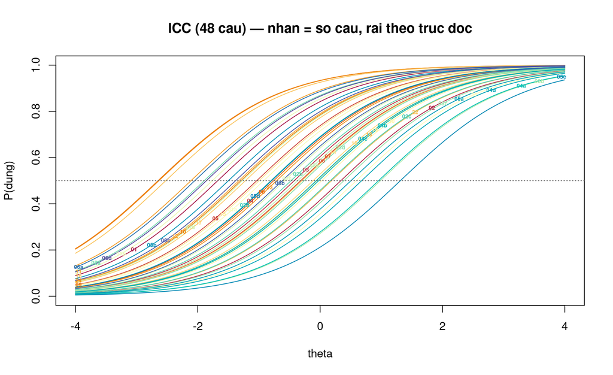

### IIC — Thông tin từng câu

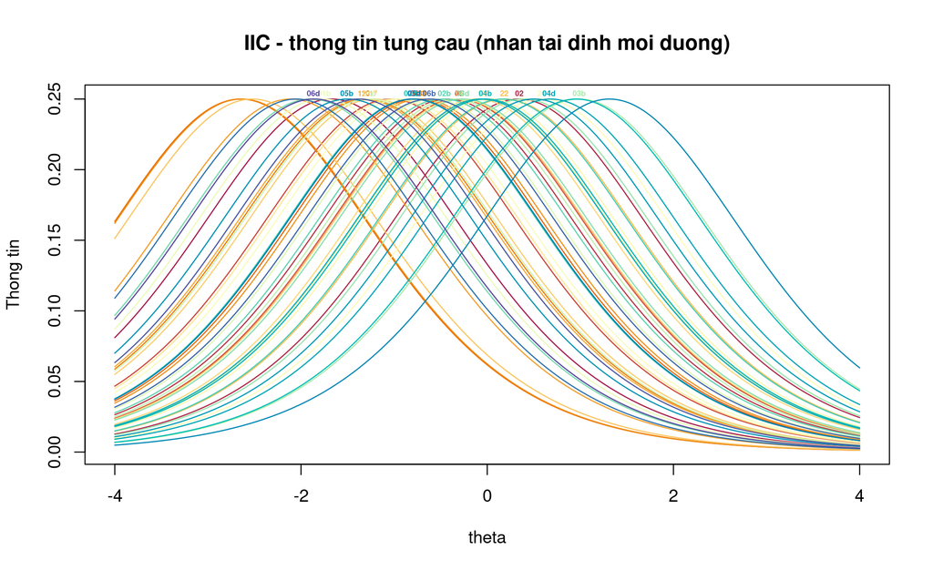

### TIF & SE(θ)

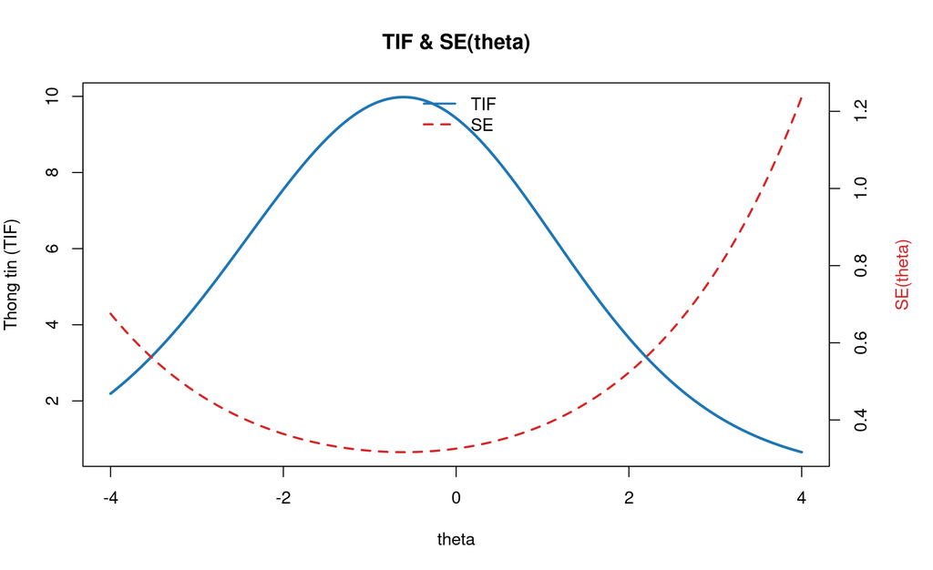

### TCC — Đường cong đặc trưng bài test

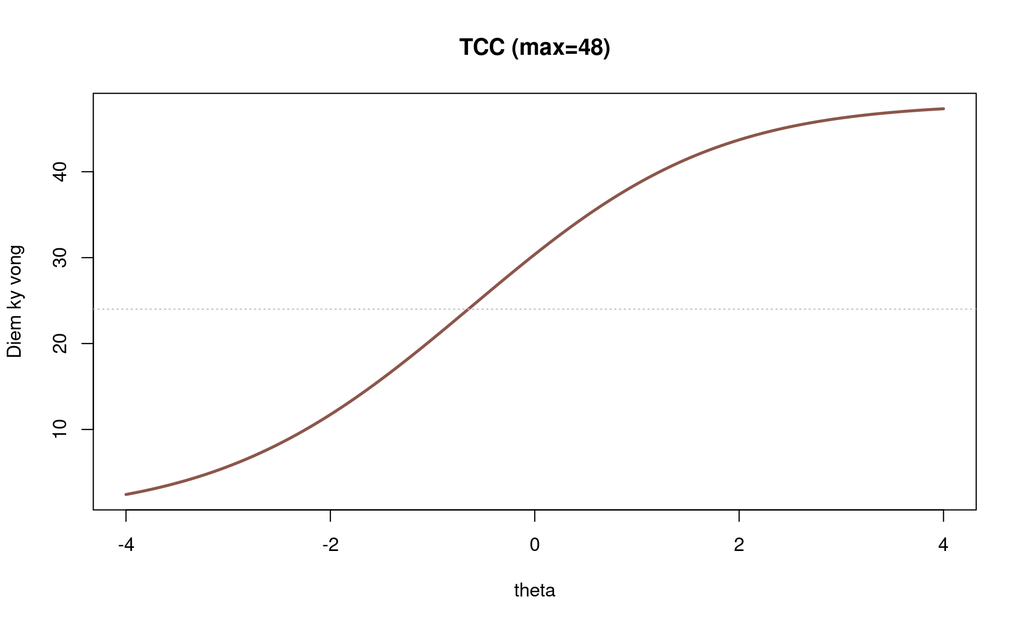

### Độ tin cậy theo năng lực

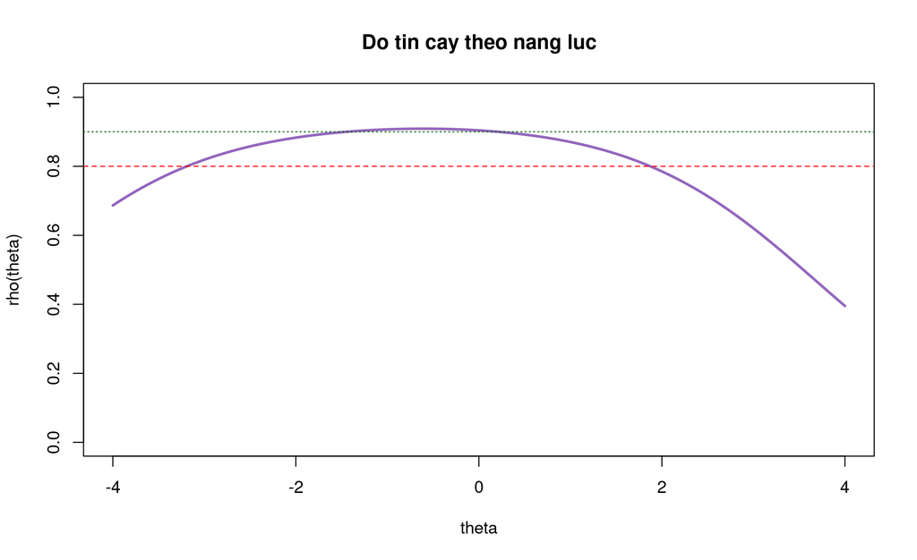

### Scatter a vs b

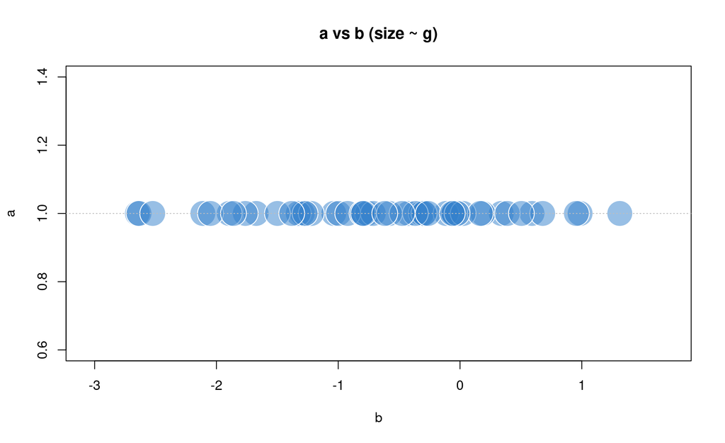

### Wright map (item–person)

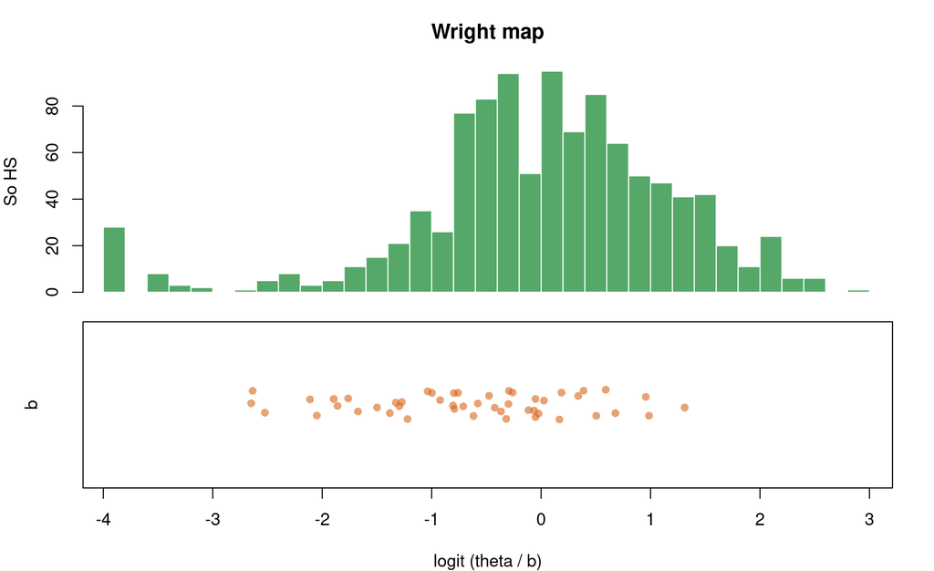

### Item fit: thực nghiệm vs mô hình

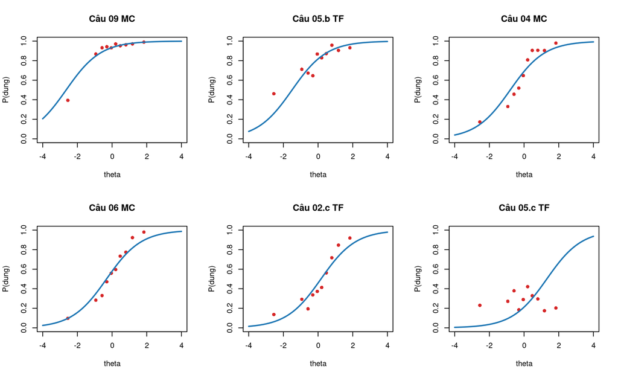

### Phụ thuộc cục bộ Q3

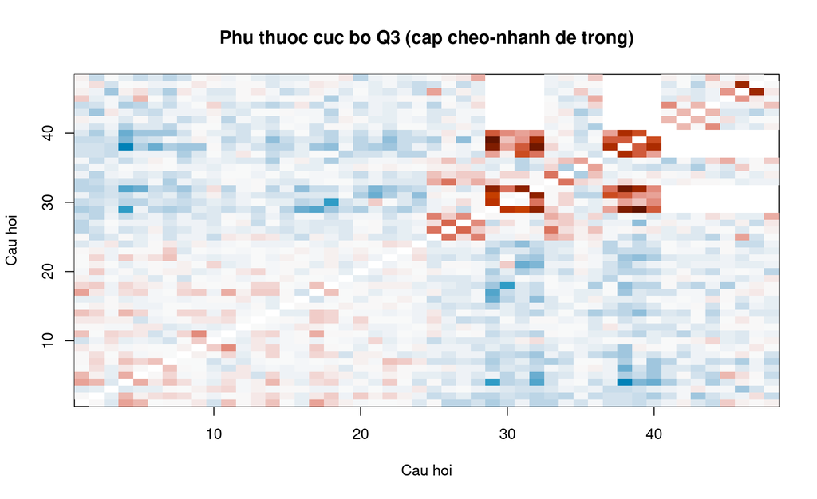

### Person fit

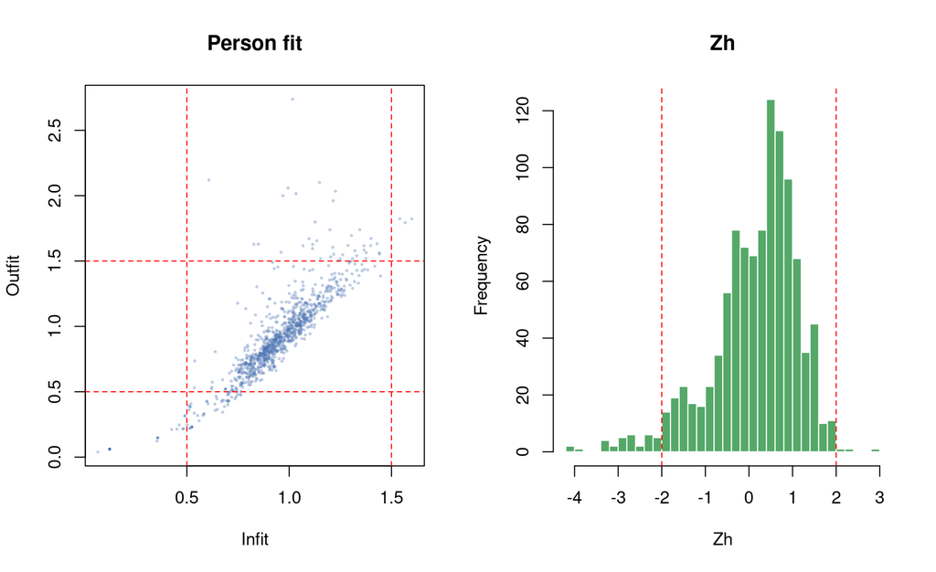

### Item fit (Bock X²)

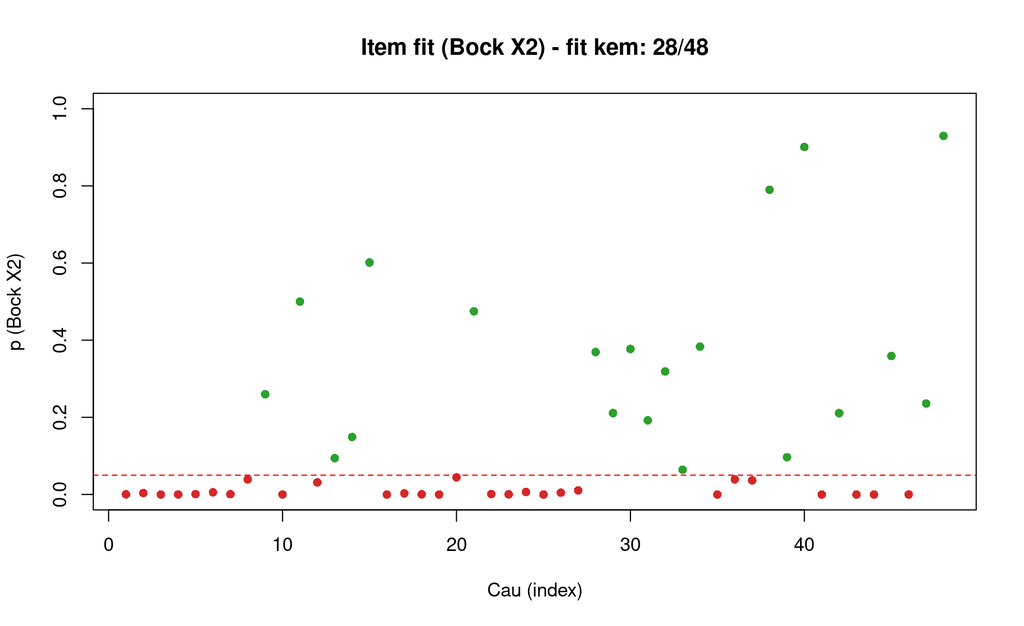

## 3.2 Mô hình 2PL

### Phân bố tham số item

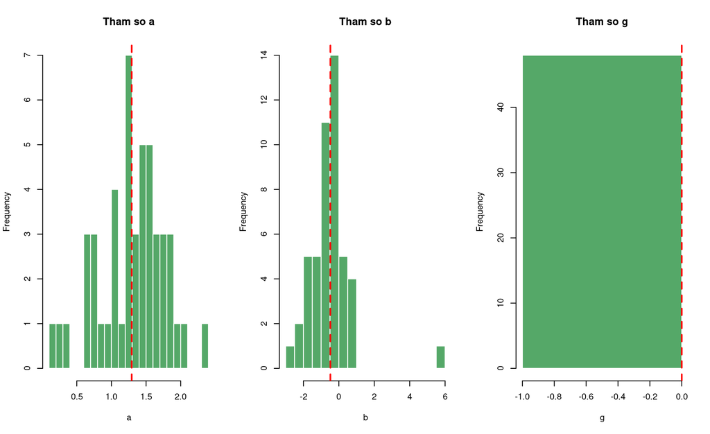

### Bảng tham số item (theo Câu)

Tham số item 2PL — cỡ mẫu N, số đúng, a, b, g (bấm cột để sắp xếp)

| Câu | Cỡ mẫu (N) | Số đúng | a | b | g |
| --- | --- | --- | --- | --- | --- |
| Câu 01 MC | 1037 | 824 | 1.606 | -1.164 | 0 |
| Câu 02 MC | 1037 | 460 | 1.456 | 0.232 | 0 |
| Câu 03 MC | 1037 | 615 | 0.670 | -0.608 | 0 |
| Câu 04 MC | 1037 | 686 | 1.597 | -0.570 | 0 |
| Câu 05 MC | 1037 | 728 | 1.568 | -0.742 | 0 |
| Câu 06 MC | 1036 | 594 | 1.547 | -0.244 | 0 |
| Câu 07 MC | 1036 | 590 | 1.250 | -0.266 | 0 |
| Câu 08 MC | 1037 | 679 | 1.032 | -0.733 | 0 |
| Câu 09 MC | 1037 | 924 | 1.573 | -1.844 | 0 |
| Câu 10 MC | 1037 | 770 | 0.782 | -1.519 | 0 |
| Câu 11 MC | 1036 | 875 | 1.849 | -1.347 | 0 |
| Câu 12 MC | 1037 | 775 | 1.428 | -1.000 | 0 |
| Câu 13 MC | 1036 | 540 | 0.945 | -0.088 | 0 |
| Câu 14 MC | 1036 | 589 | 1.225 | -0.266 | 0 |
| Câu 15 MC | 1036 | 721 | 1.073 | -0.924 | 0 |
| Câu 16 MC | 1037 | 914 | 1.921 | -1.575 | 0 |
| Câu 17 MC | 1036 | 758 | 1.778 | -0.808 | 0 |
| Câu 18 MC | 1037 | 553 | 0.656 | -0.212 | 0 |
| Câu 19 MC | 1037 | 540 | 1.077 | -0.076 | 0 |
| Câu 20 MC | 1036 | 524 | 1.202 | -0.004 | 0 |
| Câu 21 MC | 1036 | 409 | 0.727 | 0.669 | 0 |
| Câu 22 MC | 1036 | 491 | 0.684 | 0.182 | 0 |
| Câu 23 MC | 1036 | 670 | 1.432 | -0.547 | 0 |
| Câu 24 MC | 1037 | 923 | 1.732 | -1.739 | 0 |
| Câu 01.a TF | 1036 | 708 | 2.321 | -0.540 | 0 |
| Câu 01.b TF | 1036 | 835 | 2.002 | -1.083 | 0 |
| Câu 01.c TF | 1036 | 645 | 1.417 | -0.452 | 0 |
| Câu 01.d TF | 1036 | 766 | 1.360 | -0.990 | 0 |
| Câu 02.a TF | 1036 | 851 | 1.874 | -1.203 | 0 |
| Câu 02.b TF | 1036 | 625 | 1.256 | -0.408 | 0 |
| Câu 02.c TF | 1036 | 495 | 1.270 | 0.112 | 0 |
| Câu 02.d TF | 1036 | 687 | 1.079 | -0.749 | 0 |
| Câu 03.a TF | 424 | 220 | 1.678 | -0.294 | 0 |
| Câu 03.b TF | 424 | 121 | 1.288 | 0.741 | 0 |
| Câu 03.c TF | 424 | 163 | 1.677 | 0.217 | 0 |
| Câu 03.d TF | 424 | 212 | 1.593 | -0.225 | 0 |
| Câu 04.a TF | 424 | 123 | 1.833 | 0.574 | 0 |
| Câu 04.b TF | 424 | 194 | 1.334 | -0.052 | 0 |
| Câu 04.c TF | 424 | 197 | 1.498 | -0.086 | 0 |
| Câu 04.d TF | 424 | 142 | 1.327 | 0.488 | 0 |
| Câu 05.a TF | 617 | 273 | 0.320 | 0.928 | 0 |
| Câu 05.b TF | 617 | 505 | 0.714 | -2.062 | 0 |
| Câu 05.c TF | 617 | 176 | 0.162 | 5.877 | 0 |
| Câu 05.d TF | 617 | 436 | 0.286 | -2.915 | 0 |
| Câu 06.a TF | 617 | 544 | 1.123 | -1.850 | 0 |
| Câu 06.b TF | 617 | 416 | 1.743 | -0.405 | 0 |
| Câu 06.c TF | 617 | 495 | 1.260 | -1.144 | 0 |
| Câu 06.d TF | 617 | 532 | 0.820 | -2.229 | 0 |

### ICC — Đường cong đặc trưng câu hỏi

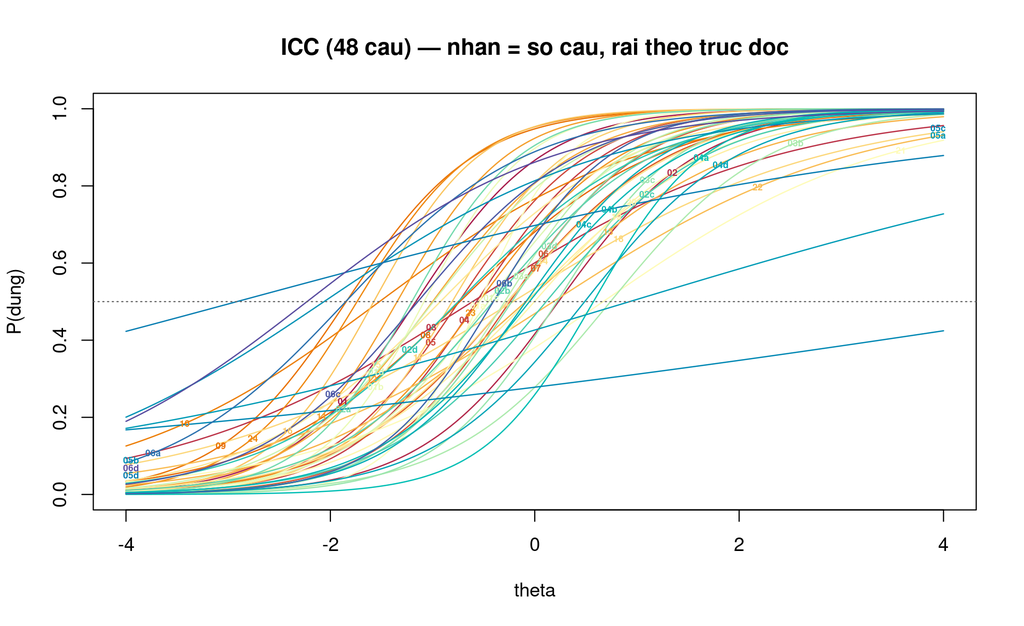

### IIC — Thông tin từng câu

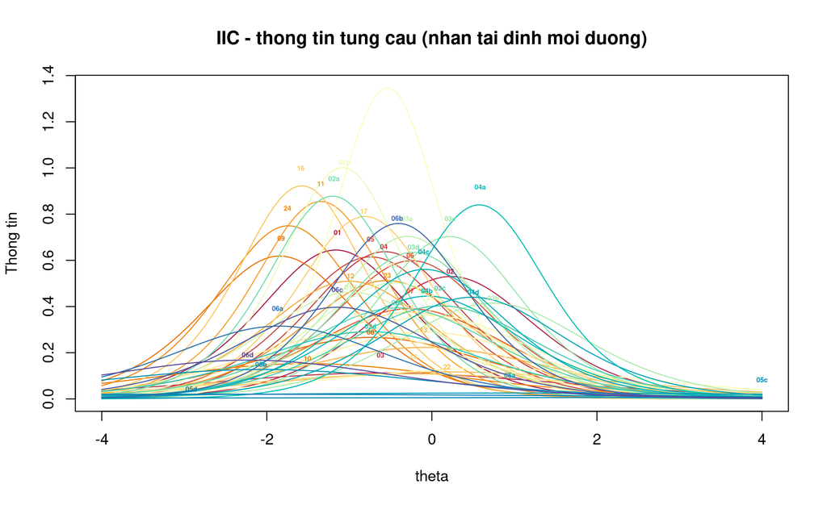

### TIF & SE(θ)

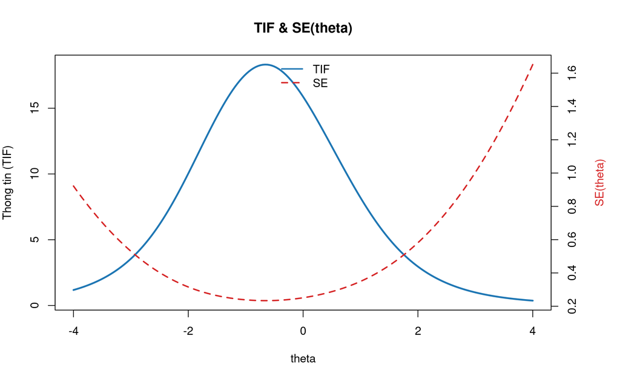

### TCC — Đường cong đặc trưng bài test

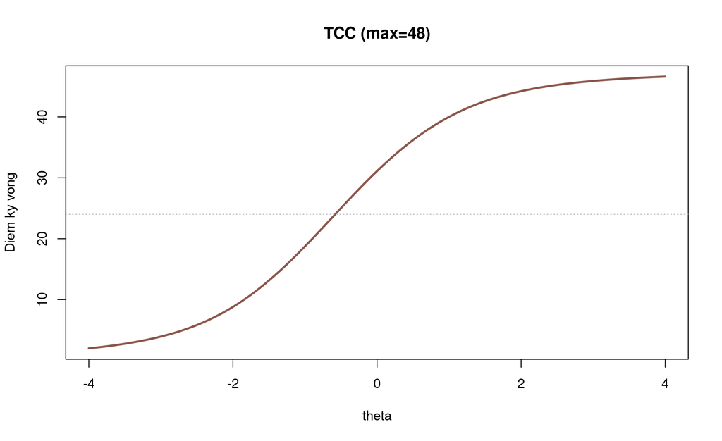

### Độ tin cậy theo năng lực

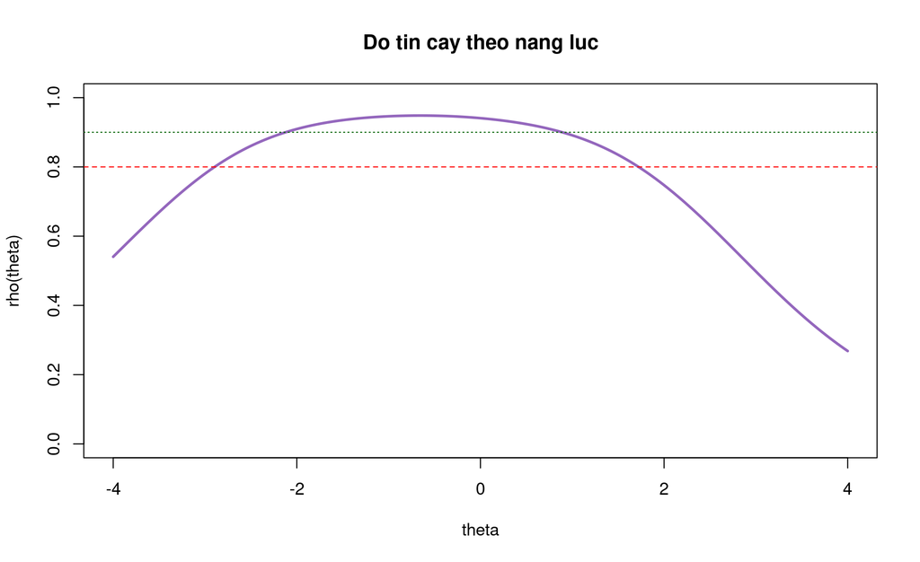

### Scatter a vs b

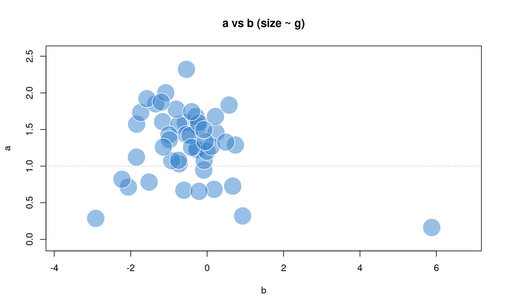

### Wright map (item–person)

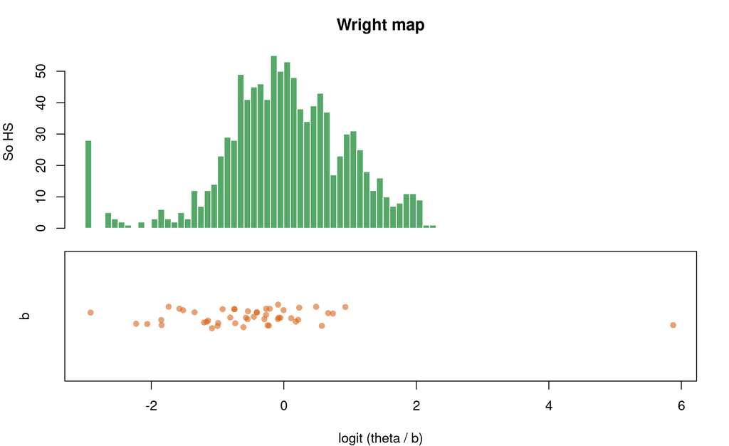

### Item fit: thực nghiệm vs mô hình

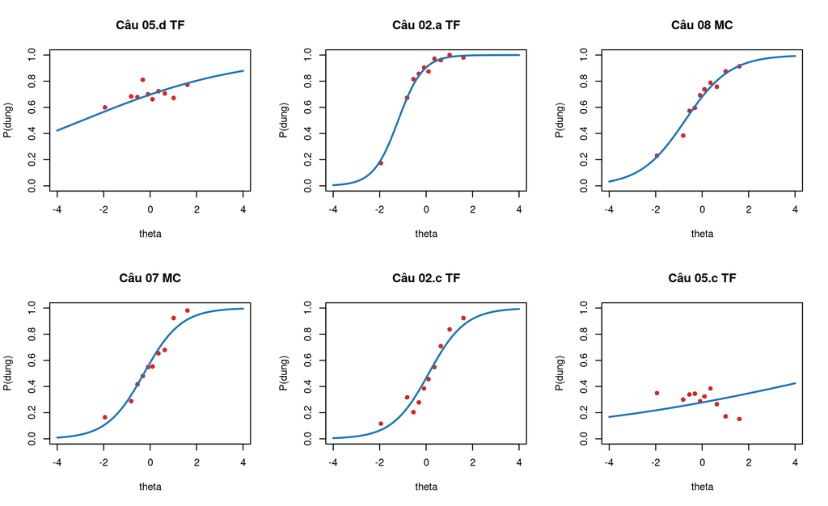

### Phụ thuộc cục bộ Q3

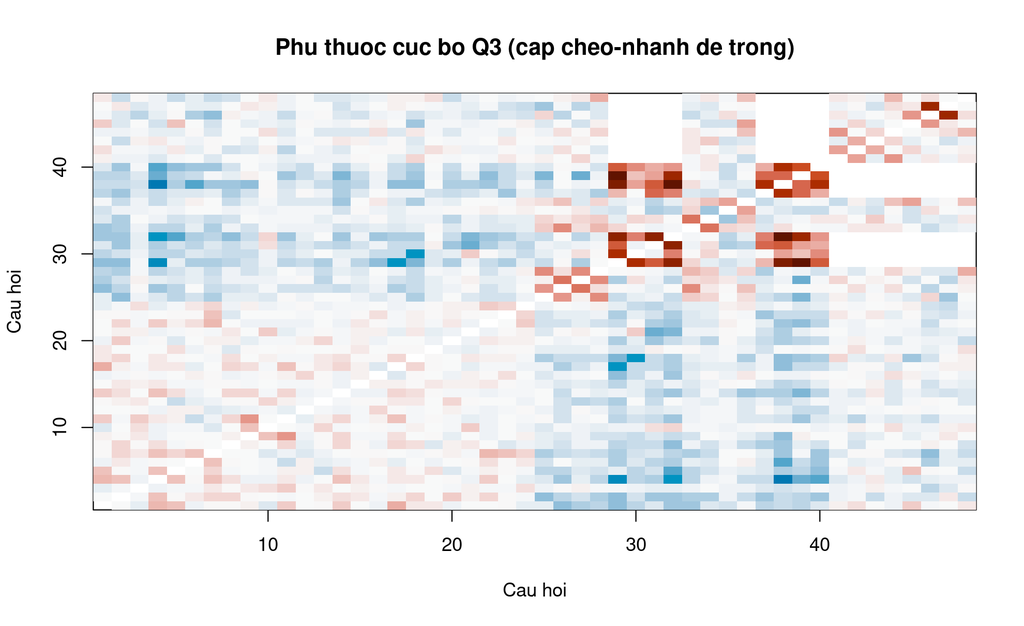

### Person fit

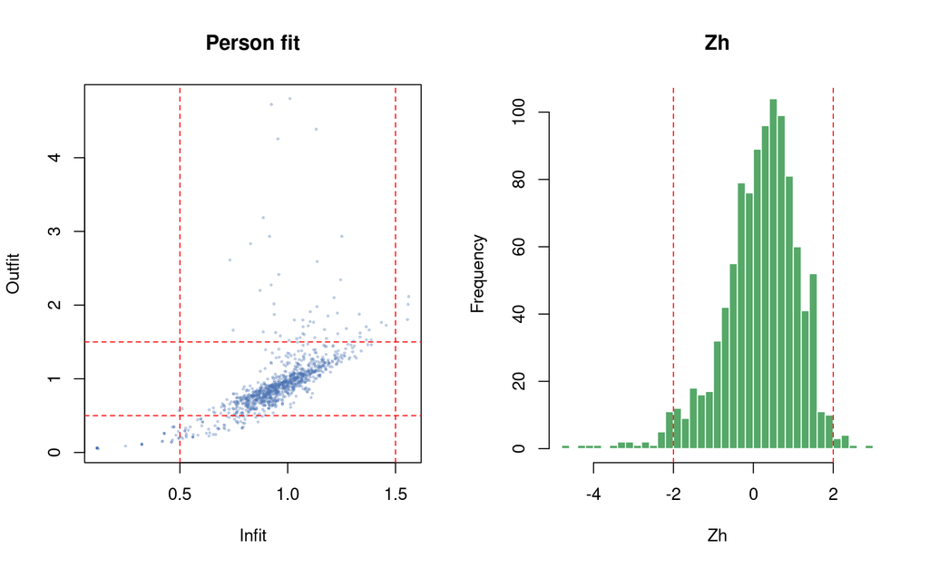

### Item fit (Bock X²)

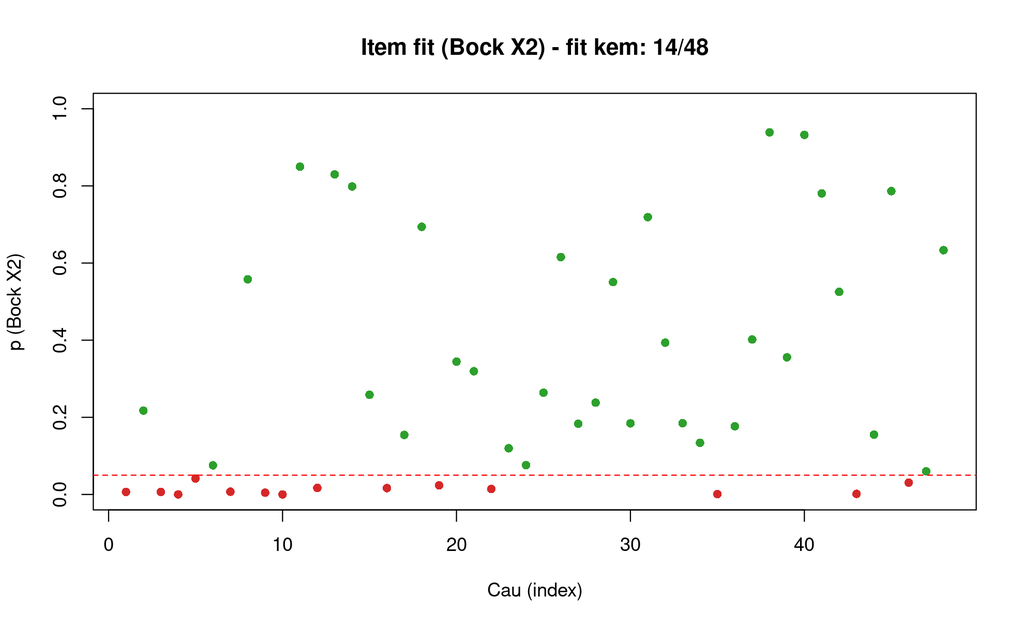

## 3.3 Mô hình 3PL

### Phân bố tham số item

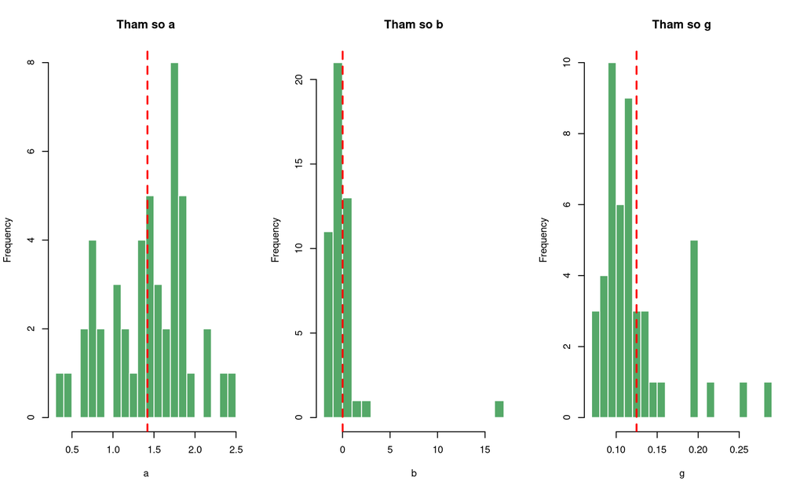

### Bảng tham số item (theo Câu)

Tham số item 3PL — cỡ mẫu N, số đúng, a, b, g (bấm cột để sắp xếp)

| Câu | Cỡ mẫu (N) | Số đúng | a | b | g |
| --- | --- | --- | --- | --- | --- |
| Câu 01 MC | 1037 | 824 | 1.806 | -0.944 | 0.143 |
| Câu 02 MC | 1037 | 460 | 1.725 | 0.392 | 0.086 |
| Câu 03 MC | 1037 | 615 | 0.691 | -0.246 | 0.120 |
| Câu 04 MC | 1037 | 686 | 1.859 | -0.365 | 0.121 |
| Câu 05 MC | 1037 | 728 | 1.744 | -0.555 | 0.118 |
| Câu 06 MC | 1036 | 594 | 1.713 | -0.069 | 0.101 |
| Câu 07 MC | 1036 | 590 | 1.474 | -0.007 | 0.126 |
| Câu 08 MC | 1037 | 679 | 1.096 | -0.504 | 0.112 |
| Câu 09 MC | 1037 | 924 | 1.573 | -1.770 | 0.114 |
| Câu 10 MC | 1037 | 770 | 0.767 | -1.310 | 0.119 |
| Câu 11 MC | 1036 | 875 | 1.822 | -1.296 | 0.099 |
| Câu 12 MC | 1037 | 775 | 1.616 | -0.769 | 0.134 |
| Câu 13 MC | 1036 | 540 | 1.011 | 0.149 | 0.097 |
| Câu 14 MC | 1036 | 589 | 1.351 | -0.049 | 0.108 |
| Câu 15 MC | 1036 | 721 | 1.090 | -0.740 | 0.108 |
| Câu 16 MC | 1037 | 914 | 2.107 | -1.423 | 0.132 |
| Câu 17 MC | 1036 | 758 | 1.849 | -0.697 | 0.095 |
| Câu 18 MC | 1037 | 553 | 0.680 | 0.132 | 0.105 |
| Câu 19 MC | 1037 | 540 | 1.305 | 0.224 | 0.131 |
| Câu 20 MC | 1036 | 524 | 1.410 | 0.238 | 0.113 |
| Câu 21 MC | 1036 | 409 | 0.838 | 1.001 | 0.104 |
| Câu 22 MC | 1036 | 491 | 0.778 | 0.617 | 0.129 |
| Câu 23 MC | 1036 | 670 | 1.562 | -0.357 | 0.111 |
| Câu 24 MC | 1037 | 923 | 1.745 | -1.667 | 0.113 |
| Câu 01.a TF | 1036 | 708 | 2.386 | -0.455 | 0.081 |
| Câu 01.b TF | 1036 | 835 | 1.920 | -1.037 | 0.097 |
| Câu 01.c TF | 1036 | 645 | 1.472 | -0.296 | 0.096 |
| Câu 01.d TF | 1036 | 766 | 1.334 | -0.885 | 0.098 |
| Câu 02.a TF | 1036 | 851 | 1.784 | -1.171 | 0.094 |
| Câu 02.b TF | 1036 | 625 | 1.260 | -0.273 | 0.082 |
| Câu 02.c TF | 1036 | 495 | 1.798 | 0.417 | 0.151 |
| Câu 02.d TF | 1036 | 687 | 1.107 | -0.542 | 0.113 |
| Câu 03.a TF | 424 | 220 | 1.764 | -0.119 | 0.100 |
| Câu 03.b TF | 424 | 121 | 1.707 | 0.917 | 0.090 |
| Câu 03.c TF | 424 | 163 | 1.801 | 0.363 | 0.074 |
| Câu 03.d TF | 424 | 212 | 1.661 | -0.051 | 0.095 |
| Câu 04.a TF | 424 | 123 | 2.422 | 0.713 | 0.077 |
| Câu 04.b TF | 424 | 194 | 1.423 | 0.171 | 0.101 |
| Câu 04.c TF | 424 | 197 | 1.595 | 0.110 | 0.097 |
| Câu 04.d TF | 424 | 142 | 1.468 | 0.677 | 0.080 |
| Câu 05.a TF | 617 | 273 | 0.456 | 2.706 | 0.256 |
| Câu 05.b TF | 617 | 505 | 0.724 | -1.633 | 0.198 |
| Câu 05.c TF | 617 | 176 | 0.779 | 16.785 | 0.282 |
| Câu 05.d TF | 617 | 436 | 0.305 | -1.479 | 0.220 |
| Câu 06.a TF | 617 | 544 | 1.119 | -1.627 | 0.192 |
| Câu 06.b TF | 617 | 416 | 2.115 | -0.120 | 0.191 |
| Câu 06.c TF | 617 | 495 | 1.323 | -0.858 | 0.195 |
| Câu 06.d TF | 617 | 532 | 0.824 | -1.898 | 0.195 |

### ICC — Đường cong đặc trưng câu hỏi

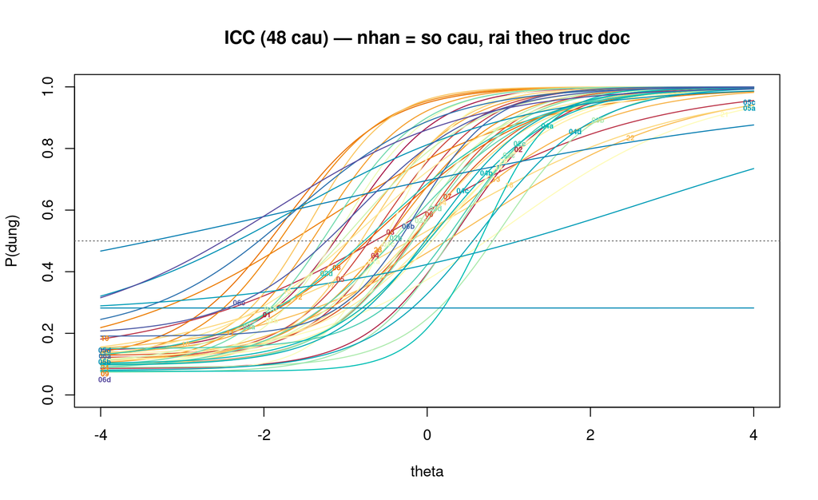

### IIC — Thông tin từng câu

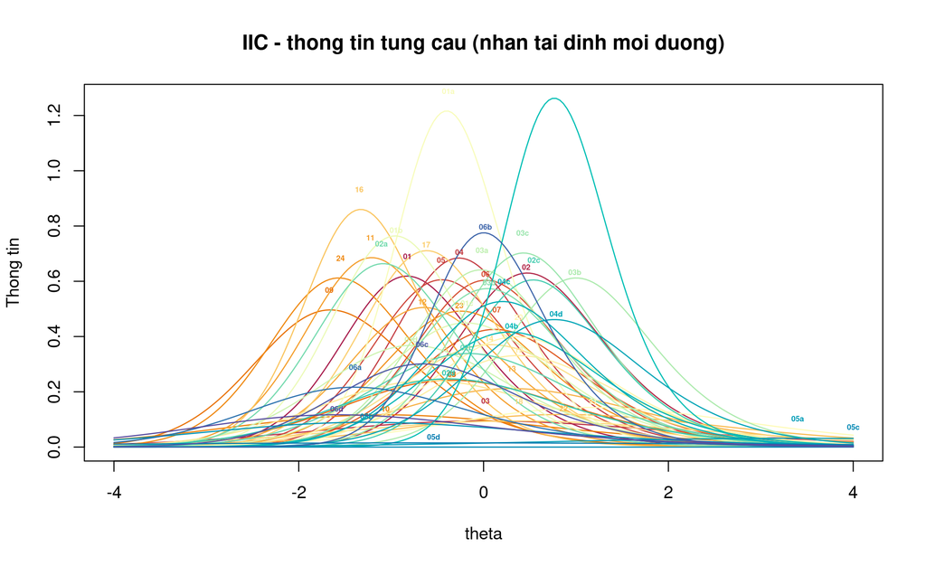

### TIF & SE(θ)

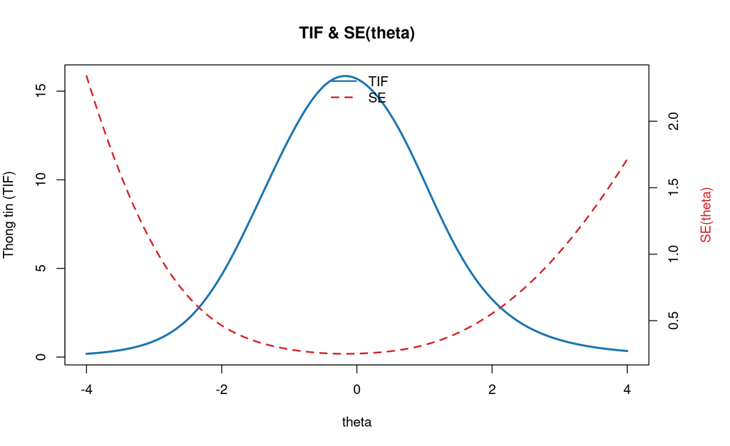

### TCC — Đường cong đặc trưng bài test

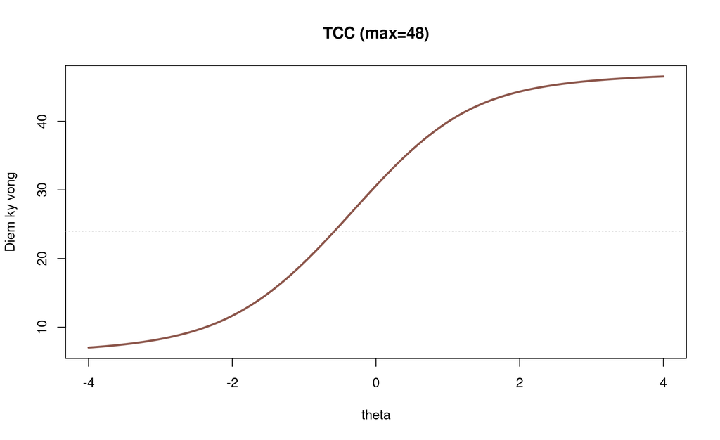

### Độ tin cậy theo năng lực

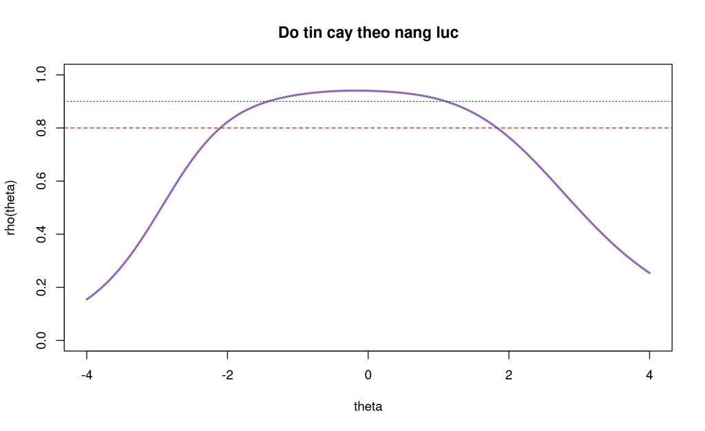